# Test Practice

Jose Zayas

2026-10-22

```r
library(dplyr)
library(gapminder)
```

### Exercise 1 – Vectors, math & functions (Assignment 1 style). Create an object called temperature with the value 98.6. Then: Print temperature. Calculate the square root of temperature * 2. Test whether temperature is greater than 100. Check the class of temperature.

```r
Temp <- 98.6
Temp2 <- sqrt(Temp*2)
Temp2
```

```
## [1] 14.04279
```

```r
if(Temp>100){
  print("Temperature is above 100")
} else {
  print("Temperature is not above 100")
}
```

```
## [1] "Temperature is not above 100"
```

```r
class(Temp)
```

```
## [1] "numeric"
```

### Exercise 2 – dplyr filtering & arranging (Assignment 3 style)

Using the gapminder dataset:Filter rows where continent == “Europe” and year == 2007. Show at least 6 rows with head(…, 6). Arrange the result in descending order of lifeExp before displaying.

```r
library(dplyr)
library(gapminder)   # needed — dplyr alone does not load the data

gapminder |>
  filter(continent == "Europe", year == 2007) |>
  arrange(desc(lifeExp)) |>
  head(6)
```

```
## # A tibble: 6 × 6
##   country     continent  year lifeExp      pop gdpPercap
##   <fct>       <fct>     <int>   <dbl>    <int>     <dbl>
## 1 Iceland     Europe     2007    81.8   301931    36181.
## 2 Switzerland Europe     2007    81.7  7554661    37506.
## 3 Spain       Europe     2007    80.9 40448191    28821.
## 4 Sweden      Europe     2007    80.9  9031088    33860.
## 5 France      Europe     2007    80.7 61083916    30470.
## 6 Italy       Europe     2007    80.5 58147733    28570.
```

### Exercise 3 – ggplot2 histogram + normality (Assignment 3 GGPLOT style)

Using the built-in trees dataset:

Create a histogram of Height with a different fill color (e.g., “steelblue”).

Run a Shapiro–Wilk test on Height and report the p-value.

State in a comment whether Height appears normally distributed (use α = 0.05).

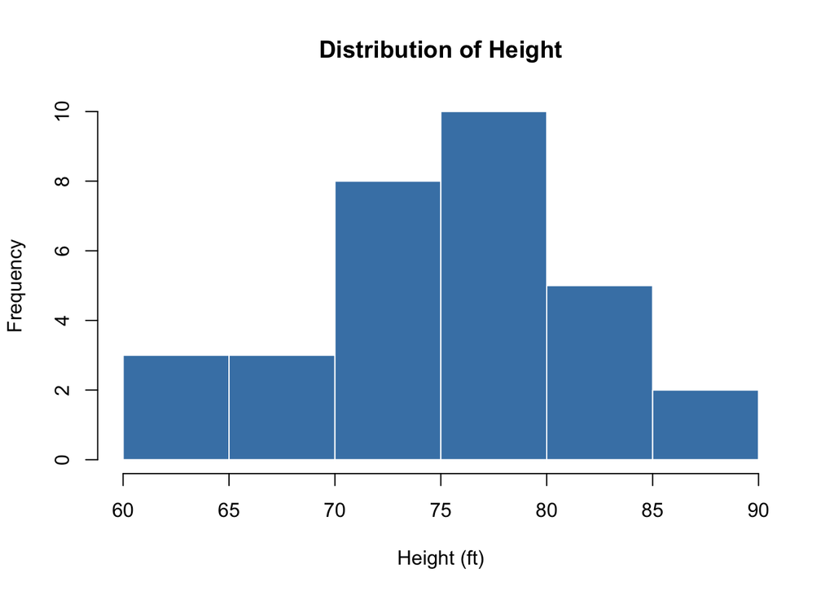

```r
library(ggplot2)
data("trees")

hist(trees$Height,
     main   = "Distribution of Height",
     xlab   = "Height (ft)",
     col    = "steelblue",
     border = "white")
```

```r
sw <- shapiro.test(trees$Height)
sw
```

```
##
##  Shapiro-Wilk normality test
##
## data:  trees$Height
## W = 0.96545, p-value = 0.4034
```

### Exercise 4 – Object manipulation & logicals. Create two objects x <- 12 and y <- 4. Then:

- Calculate x divided by y and store it in z.
- Print z.
- Test whether z is equal to 3 (use ==).
- Check the class of z.

```r
x <- 12
y <- 4
z <- x / y
z
```

```
## [1] 3
```

```r
z == 3
```

```
## [1] TRUE
```

```r
class(z)
```

```
## [1] "numeric"
```

## Exercise 5 – dplyr: select, filter, mutate (Assignment 3 style)

Using `gapminder`: - Keep only the columns `country`, `year`, and `lifeExp`. - Filter for `country == "Cambodia"`. - Create a **new column** `lifeExp_months` = `lifeExp * 12`. - Show the **first 6 rows** of the result.

```r
library(dplyr)
library(gapminder)
gapminder |>
  select(country, year, lifeExp) |>
  filter(country == "Cambodia") |>
  mutate(lifeExp_months = lifeExp * 12) |>
  head(6)
```

```
## # A tibble: 6 × 4
##   country   year lifeExp lifeExp_months
##   <fct>    <int>   <dbl>          <dbl>
## 1 Cambodia  1952    39.4           473.
## 2 Cambodia  1957    41.4           496.
## 3 Cambodia  1962    43.4           521.
## 4 Cambodia  1967    45.4           545.
## 5 Cambodia  1972    40.3           484.
## 6 Cambodia  1977    31.2           375.
```

## Exercise 6 – ggplot2 scatterplot + normality (Assignment 3 GGPLOT style)

Using the `trees` dataset: - Create a **scatterplot** of `Volume` (y-axis) vs `Girth` (x-axis), with `color = "darkgreen"`. - Run a **Shapiro–Wilk test** on `Volume`. - In a comment, report the p-value and state whether `Volume` is normally distributed at α = 0.05.

[figure not shown]

```r
library(ggplot2)
data("trees")
plot <- plot(
  trees$Girth ~ trees$Volume,
  type = "p",                      # line plot
  col = "darkgreen",                    # line color
  lwd = 2,                         # line width
  xlab = "Girth",  # x-axis label
  ylab = "Volume", # y-axis label
  main = "Relationship between Girth and Volume"
)
```

```r
sw <- shapiro.test(trees$Volume)
sw
```

```
##
##  Shapiro-Wilk normality test
##
## data:  trees$Volume
## W = 0.88757, p-value = 0.003579
```

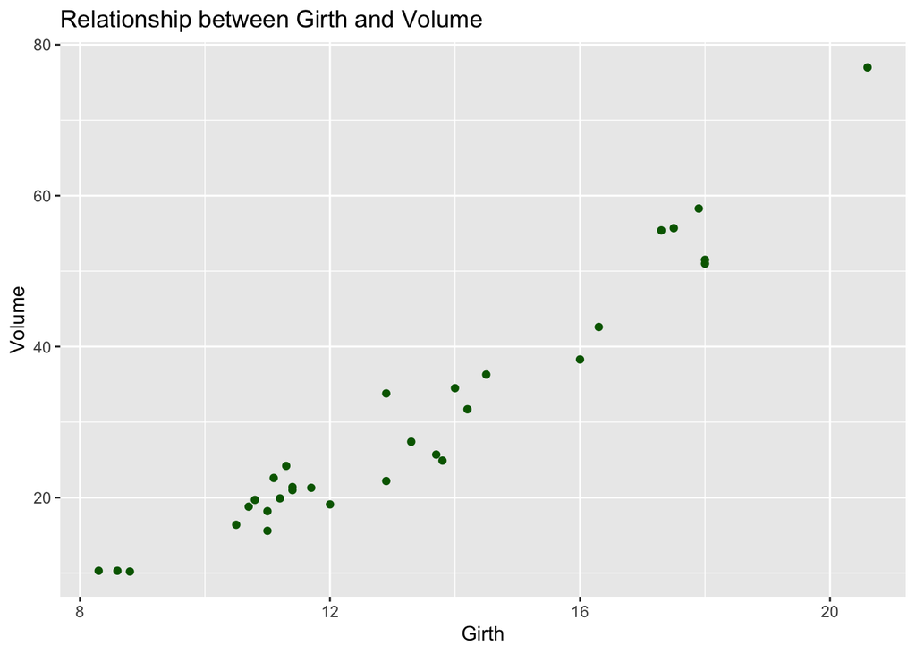

```r
ggplot(trees, aes(x = Girth, y = Volume)) +
  geom_point(color = "darkgreen") +
  labs(title = "Relationship between Girth and Volume",
       x = "Girth", y = "Volume")
```

```r
sw <- shapiro.test(trees$Volume)
sw            # W and p-value
```

```
##
##  Shapiro-Wilk normality test
##
## data:  trees$Volume
## W = 0.88757, p-value = 0.003579
```

```r
sw$p.value    # explicit p-value
```

```
## [1] 0.003578866
```

```r
# p-value < 0.05 → reject normality.
# Volume does NOT appear normally distributed at α = 0.05.
```

### Exercise 7 – Grouped summary (Assignment 3 style) Using gapminder: Filter for year == 2007. Group by continent. Summarise the mean lifeExp (call it mean_lifeExp) and the mean gdpPercap (call it mean_gdp). Show the result (all rows are fine here — only 5 continents).

```r
library(gapminder)
gapminder |>
  filter( year == "2007") |>
  group_by(continent) |>
  summarise(
    mean_lifeExp = mean(lifeExp),
    mean_gdp     = mean(gdpPercap)
  )
```

```
## # A tibble: 5 × 3
##   continent mean_lifeExp mean_gdp
##   <fct>            <dbl>    <dbl>
## 1 Africa            54.8    3089.
## 2 Americas          73.6   11003.
## 3 Asia              70.7   12473.
## 4 Europe            77.6   25054.
## 5 Oceania           80.7   29810.
```

### Exercise 8 – Chunk options: suppress a warning (Assignment 1 style)

The code below produces a warning and a NaN result. In your chunk, suppress the warning using a chunk option (do not change the code itself). Then write a comment explaining what option you used and why.

r log(-1) Hint: the option is warning = FALSE.

```r
log(-1)
```

```
## [1] NaN
```

### Exercise 9 – ggplot2 boxplot + interpretation (Assignment 3 GGPLOT style)

Using gapminder: Filter for year == 2007. Create a boxplot of lifeExp grouped by continent (x = continent, y = lifeExp), filled with “tomato”. Rotate the x-axis labels 45° so they’re readable (hint: theme(axis.text.x = element_text(angle = 45, hjust = 1))). In a comment, state which continent has the highest median life expectancy based on the plot.

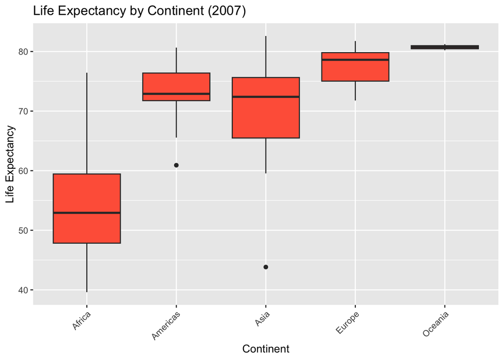

```r
library(gapminder)


gapminder |>
  filter(year == 2007) |>
  ggplot(aes(x = continent, y = lifeExp)) +
  geom_boxplot(fill = "tomato") +
  labs(title = "Life Expectancy by Continent (2007)",
       x = "Continent",
       y = "Life Expectancy") +
  theme(axis.text.x = element_text(angle = 45, hjust = 1))
```

### Exercise 10 – Counting rows per group (Assignment 3 style)

Using `gapminder`: - Filter for `year == 2007`. - **Group by** `continent`. - **Summarise** the number of countries in each continent using `n()` (call it `n_countries`). - Show the result.

```r
library(dplyr)
library(gapminder)

gapminder |>
  filter(year == 2007) |>
  group_by(continent) |>
  summarise(n_countries = n())
```

```
## # A tibble: 5 × 2
##   continent n_countries
##   <fct>           <int>
## 1 Africa             52
## 2 Americas           25
## 3 Asia               33
## 4 Europe             30
## 5 Oceania             2
```

> Hint: `n()` only works **inside** `summarise()`/`mutate()` after a `group_by()`. It returns the row count per group.

### Exercise 11 – Top N by a value (Assignment 3 style)

Using `gapminder`: - Filter for `year == 2007`. - Arrange by **descending** `gdpPercap`. - Show only the **top 6** rows (use `head(..., 6)` or `slice_max(gdpPercap, n = 6)`). - Which country has the highest GDP per capita? Answer in a comment.

```r
library(gapminder)

gapminder |>
  filter( year == 2007) |>
  arrange(desc(gdpPercap)) |>
  head(6)
```

```
## # A tibble: 6 × 6
##   country          continent  year lifeExp       pop gdpPercap
##   <fct>            <fct>     <int>   <dbl>     <int>     <dbl>
## 1 Norway           Europe     2007    80.2   4627926    49357.
## 2 Kuwait           Asia       2007    77.6   2505559    47307.
## 3 Singapore        Asia       2007    80.0   4553009    47143.
## 4 United States    Americas   2007    78.2 301139947    42952.
## 5 Ireland          Europe     2007    78.9   4109086    40676.
## 6 Hong Kong, China Asia       2007    82.2   6980412    39725.
```

### Exercise 12 – Vector stats + a line plot (mixed)

Using the built-in `trees` dataset: - Create a numeric vector `vols <- trees$Volume`. - Compute the **mean** and **median** of `vols`; print both. - Compute the **standard deviation** with `sd(vols)`; print it. - Then create a **line plot** of `Volume` over `Height` using ggplot (`geom_line()`), with `color = "purple"`.

```r
library(ggplot2)
data("trees")

# 1. Calculate the stats
vols <- trees$Volume
Vmean <- mean(vols)
Vmedian <- median(vols)
SDVol <- sd(vols)

# Print them
Vmean
```

```
## [1] 30.17097
```

```r
Vmedian
```

```
## [1] 24.2
```

```r
SDVol
```

```
## [1] 16.43785
```

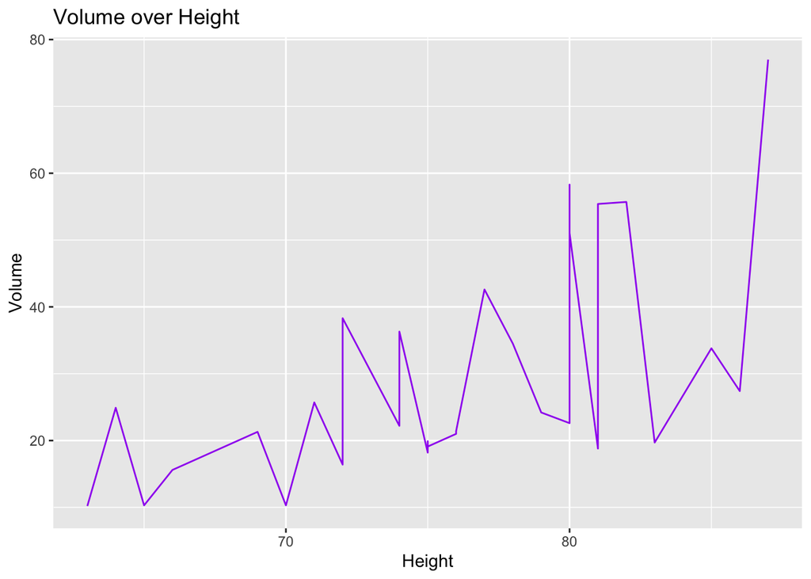

```r
# 2. The Line Plot (Volume on Y, Height on X)
ggplot(trees, aes(x = Height, y = Volume)) +
  geom_line(color = "purple") +
  labs(title = "Volume over Height",
       x = "Height", y = "Volume")
```

> Note: `geom_line()` connects points in the **order they appear in the data**, so for a meaningful line you’d normally sort by x first. For this exercise, just make the plot — no sorting required.

### Exercise 13 – Base R stats & saving objects (Assignment 1 style). Using the built-in trees dataset: Create a vector girths <- trees$Girth. Calculate the variance of girths using var() and store it in an object called girth_var. Calculate the minimum and maximum of girths using min() and max(), and store them as girth_min and girth_max. Print all three objects (girth_var, girth_min, girth_max).

```r
girths <- trees$Girth
girth_var <- var(girths)
girth_min <- min(girths)
girth_max <- max(girths)

girth_var
```

```
## [1] 9.847914
```

```r
girth_max
```

```
## [1] 20.6
```

```r
girth_min
```

```
## [1] 8.3
```